# 15 类数据原型已能生成架构选择题

从 token、图像到图与空间场，每类都已有实际训练过的候选选项，并用少量标签保留可组合的结构。

- 题型 **15 类**
- 标签 **每题 1–3 个**
- 答案依据 **三个训练 seed**

## 每行都定义了可执行的数据生成与验收

Meta 标签描述数据的结构和需要完成的操作。token、vector、image、graph、field 分别表示符号、向量、图像、图、空间场。time_series 表示随序列预测，hidden_state 表示只观测到部分状态，long_memory 表示必须保留远处信息。teacher 表示冻结神经模型提供监督，generative 表示验收实际生成样本，conditional 表示生成须符合条件。

交叉熵评价 token 概率。相对 L2 是预测误差的欧氏范数除以真实场的欧氏范数。OPD（on-policy distillation）让学生在自己生成的前缀上学习 teacher。GRU 是带门控的循环网络。

按可组合结构筛选

| 数据集／题型 | 当前输入 → 输出 | 数据怎么生成 | 如何验收 | Meta 标签 |
| --- | --- | --- | --- | --- |
| 随机小模型 next-token | 随机 8 token 前缀 → 16 token 续写 | 冻结随机 GRU，64 token 词表 | 续写位置交叉熵 | token · time_series · teacher |
| 混合阶数 token 预测 | 63 token 前缀 → 逐位置下一 token | 混合 1、2、4 阶概率表，16 token 词表 | 逐 token 交叉熵 | token · time_series |
| 带干扰的延迟复制 | 4 token 源串＋8 token 干扰＋查询 → 源串 | 独立随机 token 与固定分隔符 | 自由生成后整串错误率 | token · long_memory |
| 小型语言模型从头预训练 | 128 token 语法序列 → 下一 token | 递归语法，独立解析器检查合法性 | 有效位置交叉熵 | token · time_series |
| 从头 on-policy 蒸馏 | 学生自己生成的前缀 → teacher 概率 | 冻结随机 GRU，训练时在线查询 | 固定测试前缀上的前向 KL | token · time_series · teacher |
| 隐状态时间序列预测 | 16 步、4 维历史 → 后续 4 步观测 | 稳定隐状态递推、机制切换和观测噪声 | 未来观测均方误差 | vector · time_series · hidden_state |
| 延迟动力系统预测 | 64 步、4 维历史 → 后续 16 步向量 | 稳定递推引用 32 步前状态 | 未来向量均方误差 | vector · time_series · long_memory |
| 合成图像关系分类 | 两个 32×32 形状通道 → 四类空间关系 | 按几何规则采样位置与大小，再绘制 | 独立几何标签上的错误率 | image |
| 条件图像 diffusion | 几何条件＋噪声 → 16×16 图像 | 渲染形状，加噪后学习去噪 | 实际采样的条件不满足率 | image · generative · conditional |
| 移动形状视频预测 | 4 帧、16×16、单物体 → 后续 2 帧 | 匀速运动并在边界反弹 | 两帧直接预测均方误差 | image · time_series |
| 图上的最短路 | 32 节点图＋源节点 → 节点距离 | 连通无权图，按层遍历计算距离 | 取整距离的节点错误率 | graph |
| 图上的动态扩散 | 32 节点图＋初始值 → 后续 16 步节点值 | 归一化图上的稳定扩散递推 | 16 步直接预测均方误差 | graph · time_series |
| Poisson 解映射 | 32×32 源项、系数 → 解场 | 零边界有限差分求解，检查方程残差 | 相对 L2 解误差 | field |
| 热方程时间推进 | 32×32 初始温度、系数 → 后续 16 个场 | 周期边界 Fourier 解，检查质量与能量 | 16 个场直接预测均方误差 | field · time_series |
| 稀疏传感器场重建 | 8 步稀疏读数、观测位置 → 完整场 | 热方程演化，每步观测固定 10% 网格 | 完整场相对 L2 误差 | field · time_series · hidden_state |

## 每类题型都能打开一个真实例题

数据图展示冻结测试集中的输入和真实目标。token 数字是合成符号编号，语法题的 v0…v24 也是符号名。点击上表题型名或切换下拉框查看例题，每类有三个真实数据样本。选择题比较完整训练方案，不要求从单个样本猜出胜者。

选择例题

### 随机小模型 next-token

在同一数据与明确预算下训练，A、B、C 哪个方案的token 交叉熵最低？图展示一个数据样本；答案按完整测试集、三个训练 seed 的成绩确定。

数据样本

[figure not shown]

真实 test 样本第 0 条的第一个监督位置。8 个前缀 token 随机采样；冻结的随机初始化 GRU 给出下一 token 分布。预测目标是采样结果，概率条展示同一位置的教师分布。

选项

实际候选与训练配置

A

Transformer · 宽 16 · 深 1 · 残差开启  
Adam，学习率=0.003；交叉熵；300 步 × 16 样本

**候选模型源码**

```
from __future__ import annotations
import math
from typing import Any
import torch
from torch import nn
from torch.nn import functional as F

class CausalTransformerLM(nn.Module):
    def __init__(
        self,
        vocab_size: int,
        context_length: int,
        d_model: int,
        num_layers: int,
        num_heads: int,
        d_ff: int,
    ) -> None:
        super().__init__()
        self.context_length = context_length
        self.token_embed = nn.Embedding(vocab_size, d_model)
        self.pos_embed = nn.Embedding(context_length, d_model)
        layer = nn.TransformerEncoderLayer(
            d_model=d_model,
            nhead=num_heads,
            dim_feedforward=d_ff,
            dropout=0.0,
            batch_first=True,
            activation="gelu",
        )
        self.encoder = nn.TransformerEncoder(layer, num_layers=num_layers)
        self.head = nn.Linear(d_model, vocab_size)

    def forward(self, x: torch.Tensor) -> torch.Tensor:
        b, seq_len = x.shape
        positions = torch.arange(seq_len, device=x.device).unsqueeze(0).expand(b, -1)
        h = self.token_embed(x) + self.pos_embed(positions)
        mask = torch.triu(torch.ones(seq_len, seq_len, device=x.device), diagonal=1).bool()
        h = self.encoder(h, mask=mask)
        return self.head(h)


class TokenModel(nn.Module):
    def __init__(self, model: nn.Module) -> None:
        super().__init__()
        self.model = model

    def forward(self, x: torch.Tensor, **_: Any) -> torch.Tensor:
        return self.model(x)

def _build_module(spec: dict[str, Any]) -> nn.Module:
    kind = spec['mode']
    ins, outs = tuple(spec['input_shape']), tuple(spec['output_shape'])
    width, depth = int(spec['width']), int(spec['depth'])
    if spec['output_kind'] == 'token':
        vocab = int(spec['vocab_size'])
        if kind in {'bigram', 'ngram'}:
            return NgramLM(vocab, width, 1 if kind == 'bigram' else int(spec.get('order', 4)), depth, bool(spec['residual']))
        if kind in {'gru', 'gru_lm'}:
            return TokenModel(CausalGruLM(vocab, int(spec['context_length']), width, depth, bool(spec['residual'])))
        if kind in {'transformer', 'transformer_lm'}:
            return TokenModel(CausalTransformerLM(vocab, int(spec['context_length']), width, depth, 4, width * 2))
        raise ValueError(f'Unknown token architecture: {kind}')
    if kind == 'mlp':
        return FlatMLP(ins, outs, width, depth, bool(spec['residual']))
    if kind == 'coordinate_cnn':
        return CoordinateCNN(ins, outs, width, depth, bool(spec['residual']))
    if kind == 'clean_image_denoiser':
        return CleanImageDenoiser(ins, outs, width, depth, int(spec['noise_steps']))
    if kind in {'gnn', 'graph_transformer'}:
        return PackedGraphModel(ins, outs, width, depth, 'graph_attention' if kind == 'graph_transformer' else 'message_passing')
    if kind in {'gru', 'tcn', 'transformer'}:
        sequence_kind = ('gru_forecaster' if kind == 'gru' else
                         'tcn_forecaster' if kind == 'tcn' else 'transformer_forecaster')
        return SequenceForecaster(ins, outs, width, sequence_kind, depth)
    if kind in {'cnn', 'residual_cnn', 'fno', 'spectral_conv'}:
        spatial_kind = 'spectral_conv' if kind in {'fno', 'spectral_conv'} else 'residual_cnn' if kind == 'residual_cnn' else 'cnn'
        return SpatialModel(ins, outs, width, depth, spatial_kind, residual=bool(spec['residual']))
    if kind in {'vit', 'patch_transformer', 'field_transformer'}:
        return PatchTransformer(ins, outs, width, depth, int(spec.get('patch_size', 4)))
    raise ValueError(f'Unknown expansion architecture: {kind}')

def build_module(spec: dict[str, Any]) -> nn.Module:
    model = _build_module(spec)
    parameters = sum(p.numel() for p in model.parameters())
    cap = int(spec.get('max_parameters', 2_000_000))
    if parameters > cap:
        raise ValueError(f'Candidate exceeds parameter cap: {parameters} > {cap}')
    return model

SPEC = {'type': 'expansion_model', 'mode': 'transformer', 'width': 16, 'depth': 1, 'residual': True, 'max_parameters': 2000000, 'input_shape': [23], 'output_shape': [23], 'output_kind': 'token', 'vocab_size': 64, 'noise_steps': 100, 'context_length': 40}
class Model(nn.Module):
    def __init__(self):
        super().__init__()
        self.net = build_module(SPEC)

    def forward(self, x):
        return self.net(x)
```

B

Transformer · 宽 48 · 深 3 · 残差开启  
Adam，学习率=0.003；交叉熵；300 步 × 16 样本

**候选模型源码**

```
from __future__ import annotations
import math
from typing import Any
import torch
from torch import nn
from torch.nn import functional as F

class CausalTransformerLM(nn.Module):
    def __init__(
        self,
        vocab_size: int,
        context_length: int,
        d_model: int,
        num_layers: int,
        num_heads: int,
        d_ff: int,
    ) -> None:
        super().__init__()
        self.context_length = context_length
        self.token_embed = nn.Embedding(vocab_size, d_model)
        self.pos_embed = nn.Embedding(context_length, d_model)
        layer = nn.TransformerEncoderLayer(
            d_model=d_model,
            nhead=num_heads,
            dim_feedforward=d_ff,
            dropout=0.0,
            batch_first=True,
            activation="gelu",
        )
        self.encoder = nn.TransformerEncoder(layer, num_layers=num_layers)
        self.head = nn.Linear(d_model, vocab_size)

    def forward(self, x: torch.Tensor) -> torch.Tensor:
        b, seq_len = x.shape
        positions = torch.arange(seq_len, device=x.device).unsqueeze(0).expand(b, -1)
        h = self.token_embed(x) + self.pos_embed(positions)
        mask = torch.triu(torch.ones(seq_len, seq_len, device=x.device), diagonal=1).bool()
        h = self.encoder(h, mask=mask)
        return self.head(h)


class TokenModel(nn.Module):
    def __init__(self, model: nn.Module) -> None:
        super().__init__()
        self.model = model

    def forward(self, x: torch.Tensor, **_: Any) -> torch.Tensor:
        return self.model(x)

def _build_module(spec: dict[str, Any]) -> nn.Module:
    kind = spec['mode']
    ins, outs = tuple(spec['input_shape']), tuple(spec['output_shape'])
    width, depth = int(spec['width']), int(spec['depth'])
    if spec['output_kind'] == 'token':
        vocab = int(spec['vocab_size'])
        if kind in {'bigram', 'ngram'}:
            return NgramLM(vocab, width, 1 if kind == 'bigram' else int(spec.get('order', 4)), depth, bool(spec['residual']))
        if kind in {'gru', 'gru_lm'}:
            return TokenModel(CausalGruLM(vocab, int(spec['context_length']), width, depth, bool(spec['residual'])))
        if kind in {'transformer', 'transformer_lm'}:
            return TokenModel(CausalTransformerLM(vocab, int(spec['context_length']), width, depth, 4, width * 2))
        raise ValueError(f'Unknown token architecture: {kind}')
    if kind == 'mlp':
        return FlatMLP(ins, outs, width, depth, bool(spec['residual']))
    if kind == 'coordinate_cnn':
        return CoordinateCNN(ins, outs, width, depth, bool(spec['residual']))
    if kind == 'clean_image_denoiser':
        return CleanImageDenoiser(ins, outs, width, depth, int(spec['noise_steps']))
    if kind in {'gnn', 'graph_transformer'}:
        return PackedGraphModel(ins, outs, width, depth, 'graph_attention' if kind == 'graph_transformer' else 'message_passing')
    if kind in {'gru', 'tcn', 'transformer'}:
        sequence_kind = ('gru_forecaster' if kind == 'gru' else
                         'tcn_forecaster' if kind == 'tcn' else 'transformer_forecaster')
        return SequenceForecaster(ins, outs, width, sequence_kind, depth)
    if kind in {'cnn', 'residual_cnn', 'fno', 'spectral_conv'}:
        spatial_kind = 'spectral_conv' if kind in {'fno', 'spectral_conv'} else 'residual_cnn' if kind == 'residual_cnn' else 'cnn'
        return SpatialModel(ins, outs, width, depth, spatial_kind, residual=bool(spec['residual']))
    if kind in {'vit', 'patch_transformer', 'field_transformer'}:
        return PatchTransformer(ins, outs, width, depth, int(spec.get('patch_size', 4)))
    raise ValueError(f'Unknown expansion architecture: {kind}')

def build_module(spec: dict[str, Any]) -> nn.Module:
    model = _build_module(spec)
    parameters = sum(p.numel() for p in model.parameters())
    cap = int(spec.get('max_parameters', 2_000_000))
    if parameters > cap:
        raise ValueError(f'Candidate exceeds parameter cap: {parameters} > {cap}')
    return model

SPEC = {'type': 'expansion_model', 'mode': 'transformer', 'width': 48, 'depth': 3, 'residual': True, 'max_parameters': 2000000, 'input_shape': [23], 'output_shape': [23], 'output_kind': 'token', 'vocab_size': 64, 'noise_steps': 100, 'context_length': 40}
class Model(nn.Module):
    def __init__(self):
        super().__init__()
        self.net = build_module(SPEC)

    def forward(self, x):
        return self.net(x)
```

C

ngram · 宽 32 · 深 3 · 残差关闭  
Adam，学习率=0.003；交叉熵；300 步 × 16 样本

**候选模型源码**

```
from __future__ import annotations
import math
from typing import Any
import torch
from torch import nn
from torch.nn import functional as F

class NgramLM(nn.Module):
    def __init__(self, vocab: int, width: int, order: int, depth: int = 1,
                 residual: bool = False) -> None:
        super().__init__()
        self.embedding = nn.Embedding(vocab, width)
        self.mix = nn.ModuleList(nn.Conv1d(width, width, order) for _ in range(depth))
        self.head = nn.Linear(width, vocab)
        self.order = order
        self.residual = residual

    def forward(self, x: torch.Tensor, **_: Any) -> torch.Tensor:
        h = self.embedding(x).transpose(1, 2)
        for layer in self.mix:
            z = F.gelu(layer(F.pad(h, (self.order - 1, 0))))
            h = h + z if self.residual else z
        return self.head(h.transpose(1, 2))

def _build_module(spec: dict[str, Any]) -> nn.Module:
    kind = spec['mode']
    ins, outs = tuple(spec['input_shape']), tuple(spec['output_shape'])
    width, depth = int(spec['width']), int(spec['depth'])
    if spec['output_kind'] == 'token':
        vocab = int(spec['vocab_size'])
        if kind in {'bigram', 'ngram'}:
            return NgramLM(vocab, width, 1 if kind == 'bigram' else int(spec.get('order', 4)), depth, bool(spec['residual']))
        if kind in {'gru', 'gru_lm'}:
            return TokenModel(CausalGruLM(vocab, int(spec['context_length']), width, depth, bool(spec['residual'])))
        if kind in {'transformer', 'transformer_lm'}:
            return TokenModel(CausalTransformerLM(vocab, int(spec['context_length']), width, depth, 4, width * 2))
        raise ValueError(f'Unknown token architecture: {kind}')
    if kind == 'mlp':
        return FlatMLP(ins, outs, width, depth, bool(spec['residual']))
    if kind == 'coordinate_cnn':
        return CoordinateCNN(ins, outs, width, depth, bool(spec['residual']))
    if kind == 'clean_image_denoiser':
        return CleanImageDenoiser(ins, outs, width, depth, int(spec['noise_steps']))
    if kind in {'gnn', 'graph_transformer'}:
        return PackedGraphModel(ins, outs, width, depth, 'graph_attention' if kind == 'graph_transformer' else 'message_passing')
    if kind in {'gru', 'tcn', 'transformer'}:
        sequence_kind = ('gru_forecaster' if kind == 'gru' else
                         'tcn_forecaster' if kind == 'tcn' else 'transformer_forecaster')
        return SequenceForecaster(ins, outs, width, sequence_kind, depth)
    if kind in {'cnn', 'residual_cnn', 'fno', 'spectral_conv'}:
        spatial_kind = 'spectral_conv' if kind in {'fno', 'spectral_conv'} else 'residual_cnn' if kind == 'residual_cnn' else 'cnn'
        return SpatialModel(ins, outs, width, depth, spatial_kind, residual=bool(spec['residual']))
    if kind in {'vit', 'patch_transformer', 'field_transformer'}:
        return PatchTransformer(ins, outs, width, depth, int(spec.get('patch_size', 4)))
    raise ValueError(f'Unknown expansion architecture: {kind}')

def build_module(spec: dict[str, Any]) -> nn.Module:
    model = _build_module(spec)
    parameters = sum(p.numel() for p in model.parameters())
    cap = int(spec.get('max_parameters', 2_000_000))
    if parameters > cap:
        raise ValueError(f'Candidate exceeds parameter cap: {parameters} > {cap}')
    return model

SPEC = {'type': 'expansion_model', 'mode': 'ngram', 'width': 32, 'depth': 3, 'residual': False, 'max_parameters': 2000000, 'input_shape': [23], 'output_shape': [23], 'output_kind': 'token', 'vocab_size': 64, 'noise_steps': 100, 'context_length': 40}
class Model(nn.Module):
    def __init__(self):
        super().__init__()
        self.net = build_module(SPEC)

    def forward(self, x):
        return self.net(x)
```

**揭晓答案与实测依据**

正确答案：**A**。按 test_ce 比较，越低越好。以下是整体测试成绩，不是图中单个样本的误差。

| 选项 | 三 seed 均值 | 各 seed 成绩 |
| --- | --- | --- |
| A | 3.48457 | 3.48056，3.48245，3.4907 |
| B | 4.0226 | 3.95094，4.12905，3.98782 |
| C | 3.64724 | 3.61735，3.69692，3.62744 |

**完整冻结题面**

````
You are taking the ArchitectureIQ benchmark.

Each question describes one **dataset instance** and several **choices** (each choice is one **candidate**: model, optimizer, loss, and training budget). All choices train on the same dataset instance. Each choice's training budget (`total_samples_seen`) is stated in the prompt — either shared across all choices or specified per choice in the Sample budget section. Your task is to identify which choice will achieve the **best test metric** on the held-out test set after its stated training budget — using architecture and learning-mechanics reasoning only (no training results are provided).

The reply format is defined once, in the final "Your answer" section.

## Dataset
Random frozen GRU language modeling: independent random token prefixes are continued by a single frozen, calibrated neural teacher. Predict next-token distributions only at supervised continuation positions. The teacher is shared across all splits; token targets of -100 are ignored.

### Synthesis (PyTorch)
```python
from __future__ import annotations
import hashlib
import math
from typing import Any
import torch
import torch.nn.functional as F

def _seed(seed: int, task: str, stream: str) -> int:
    return int.from_bytes(hashlib.sha256(f'{seed}|{task}|{stream}'.encode()).digest()[:8], 'little') % (2 ** 63 - 1)

class FrozenTeacher(torch.nn.Module):

    def __init__(self, config: dict, state: dict | None=None):
        super().__init__()
        self.net = TeacherNet(config['vocab_size'], config['teacher_width'], config['teacher_layers'])
        if state is not None:
            self.net.load_state_dict(state)
        self.scale = float(config['logit_scale']) / float(config['temperature'])
        self.requires_grad_(False)
        self.eval()

    def forward(self, x):
        return self.net(x) * self.scale

class TeacherNet(torch.nn.Module):

    def __init__(self, vocab, width, layers):
        super().__init__()
        self.token_embed = torch.nn.Embedding(vocab, width)
        self.gru = torch.nn.GRU(width, width, layers, batch_first=True)
        self.head = torch.nn.Linear(width, vocab)

    def forward(self, x):
        (h, _) = self.gru(self.token_embed(x))
        return self.head(h)

def _teacher_split(teacher, config, n, rng, prefix_length, continuation):
    seq = torch.randint(config['vocab_size'], (n, prefix_length), generator=rng)
    for _ in range(continuation):
        with torch.no_grad():
            probs = teacher(seq)[:, -1].softmax(-1)
        seq = torch.cat([seq, torch.multinomial(probs, 1, generator=rng)], 1)
    (x, y) = (seq[:, :-1], seq[:, 1:])
    with torch.no_grad():
        p = teacher(x).softmax(-1)
    mask = torch.zeros_like(x, dtype=torch.bool)
    mask[:, prefix_length - 1:] = True
    return {'x': x, 'y': y, 'mask': mask, 'teacher_probs': p}

def build(task_id: str, parameters: dict[str, Any], split_counts: dict[str, int], seed: int, data_seed: int | None=None):
    cfg = {'task_id': 'random_teacher_ntp'}
    (artifacts, metadata) = ({}, {})
    generator = torch.Generator().manual_seed(_seed(seed, 'random_teacher_ntp', 'generator'))
    teacher_cfg = parameters.get('teacher', {})
    prefix = int(parameters.get('prefix_length', min(parameters.get('prefix_lengths', [8]))))
    continuation = int(parameters.get('continuation_length', parameters.get('rollout_length', min(parameters.get('continuation_lengths', [16])))))
    cfg.update(vocab_size=int(parameters.get('vocab', 64)), prefix_length=prefix, continuation_length=continuation, rollout_length=continuation, context_length=prefix + 2 * continuation, teacher_width=int(teacher_cfg.get('width', 64)), teacher_layers=int(teacher_cfg.get('layers', 2)), temperature=float(teacher_cfg.get('temperature', 1.0)), logit_scale=float(teacher_cfg.get('logit_scale', parameters.get('logit_scale', 8.0))))
    with torch.random.fork_rng():
        torch.manual_seed(_seed(seed, 'random_teacher_ntp', 'teacher_weights'))
        teacher = FrozenTeacher(cfg)
    probe = torch.randint(cfg['vocab_size'], (128, int(parameters.get('teacher_probe_context', 8))), generator=generator)
    with torch.no_grad():
        for _ in range(12):
            p = teacher(probe).softmax(-1)[:, -1]
            entropy = float(-(p * p.clamp_min(1e-12).log()).sum(-1).mean())
            ratio = entropy / math.log(cfg['vocab_size'])
            if 0.35 <= ratio <= 0.88:
                break
            teacher.scale *= 1.5 if ratio > 0.88 else 0.7
        reset_p = teacher(probe[:, -1:]).softmax(-1)[:, -1]
        context_gap = float((p * (p.clamp_min(1e-12).log() - reset_p.clamp_min(1e-12).log())).sum(-1).mean())
    if not 0.35 <= ratio <= 0.88 or context_gap < 0.001:
        raise ValueError('Random teacher has insufficient entropy or context dependence')
    cfg['logit_scale'] = teacher.scale * cfg['temperature']
    artifacts['teacher_state'] = {k: v.detach().clone() for (k, v) in teacher.net.state_dict().items()}
    metadata.update(teacher_probe_entropy=entropy, teacher_context_kl_gap=context_gap, teacher_architecture='frozen_random_causal_gru', teacher_seed=_seed(seed, 'random_teacher_ntp', 'teacher_weights'), teacher_probe_scope='generator_only_not_test_selection')
    cfg.update(selection_metric='token_ce', higher_is_better=False)
    splits = {}
    seen_grammar = set()
    for (split, count) in split_counts.items():
        rng = torch.Generator().manual_seed(_seed(seed, 'random_teacher_ntp', split) if data_seed is None else data_seed)
        ood = split == 'ood'
        splits[split] = _teacher_split(teacher, cfg, count, rng, prefix, continuation * (2 if ood else 1))
    metadata.update(split_unit='whole_independently_sampled_sequence', seed_streams={s: _seed(seed, 'random_teacher_ntp', s) for s in ['generator', *split_counts]}, ood_axis={'random_teacher_ntp': 'continuation_length_x2', 'on_policy_distillation': 'continuation_length_x2', 'variable_order_markov': 'sequence_length_x2', 'copy_recall': 'distractor_length_x2', 'grammar_pretrain': 'terminal_frequency_shift', 'switching_state_space': 'switch_probability_x2', 'delay_dynamics': 'noise_scale_x1.8'}['random_teacher_ntp'])
    cfg['input_shape'] = list(splits['train']['x'].shape[1:])
    cfg['output_shape'] = list(splits['train']['y'].shape[1:])
    if 'vocab_size' in cfg:
        cfg['max_sequence_length'] = max((int(b['x'].shape[1]) for b in splits.values()))
    metadata['split_sizes'] = {s: len(b['x']) for (s, b) in splits.items()}
    return {'config': cfg, 'splits': splits, 'metadata': metadata, 'artifacts': artifacts}
````

````
def _canonical_parameters(params):
    p = dict(params)
    p['vocab'] = p.get('vocab_size', 64)
    p['sequence_length'] = p.get('context_length', 128) + (0 if p.get('task_id') == 'grammar_pretrain' else 1)
    p['teacher'] = {'width': p.get('teacher_width', 64), 'layers': p.get('teacher_layers', 2), 'temperature': p.get('temperature', 1.0), 'logit_scale': p.get('logit_scale', 8.0)}
    return p

def synthesize_task(name, params, seed, count):
    parameters = _canonical_parameters(dict(params, task_id='random_teacher_ntp'))
    dataset = build('random_teacher_ntp', parameters, {'train': count}, int(params['structure_seed']), data_seed=seed)
    batch = dataset['splits']['train']
    batch['y'] = batch['y'].clone()
    batch['y'][~batch['mask']] = -100
    return batch
TASK = 'random_teacher_ntp'
PARAMS = {'vocab_size': 64, 'prefix_length': 8, 'continuation_length': 16, 'context_length': 40, 'teacher_width': 64, 'teacher_layers': 2, 'temperature': 1.0, 'logit_scale': 8.0, 'train_size': 512, 'test_size': 128, 'validation_size': 128, 'ood_size': 128, 'instance_seed': 11, 'structure_seed': 10011, 'teacher_seed': 10011, 'ood_shift': {'prefix_length': 16, 'continuation_length': 8}, 'input_shape': [23], 'output_shape': [23], 'model_modes': ['bigram', 'ngram', 'gru', 'transformer'], 'objective': 'token_ce', 'output_kind': 'token'}

def synthesize_split(seed, count, overrides=None):
    global PARAMS
    original = PARAMS
    PARAMS = dict(PARAMS, **overrides or {})
    try:
        return synthesize_task(TASK, PARAMS, seed, count)
    finally:
        PARAMS = original

def synthesize():
    tr = synthesize_split(PARAMS['instance_seed'] + 20000, PARAMS['train_size'])
    te = synthesize_split(PARAMS['instance_seed'] + 40000, PARAMS['test_size'])
    return (tr['x'], tr['y'], te['x'], te['y'])
```

### Data splits and training protocol
- Train / validation / test size: 512 / 128 / 128
- Split by complete sequences, trajectories, graphs or initial conditions; no overlapping split windows.
- Objective: token_ce; model input/output shapes: [23] → [23].
- Curves use validation. Final ranking uses held-out test without selecting checkpoints.
- Execution device: cpu.

## Sample budget (same for all choices)
- training_steps: 300
- batch_size: 16
- total_samples_seen: 4800 (= training_steps × batch_size)

## Evaluation metric
- Ground-truth ranking uses **test_ce** on the held-out test split.
- Each choice is trained independently for **3** seeds (`0`..`2`), one `torch.manual_seed(seed)` per run.
- Execution device: cpu.
- The correct choice has the lowest **mean** test_ce across seeds.

## Choices

### Choice A

**Model (natural language)**
- type: expansion_model
- mode: transformer
- width: 16
- depth: 1
- residual: True
- max_parameters: 2000000
- input_shape: [23]
- output_shape: [23]
- output_kind: token
- vocab_size: 64
- noise_steps: 100
- context_length: 40

**Model code**
```python
SPEC = {'type': 'expansion_model', 'mode': 'transformer', 'width': 16, 'depth': 1, 'residual': True, 'max_parameters': 2000000, 'input_shape': [23], 'output_shape': [23], 'output_kind': 'token', 'vocab_size': 64, 'noise_steps': 100, 'context_length': 40}


def _build_module(spec: dict[str, Any]) -> nn.Module:
    kind = spec['mode']
    ins, outs = tuple(spec['input_shape']), tuple(spec['output_shape'])
    width, depth = int(spec['width']), int(spec['depth'])
    if spec['output_kind'] == 'token':
        vocab = int(spec['vocab_size'])
        if kind in {'bigram', 'ngram'}:
            return NgramLM(vocab, width, 1 if kind == 'bigram' else int(spec.get('order', 4)), depth, bool(spec['residual']))
        if kind in {'gru', 'gru_lm'}:
            return TokenModel(CausalGruLM(vocab, int(spec['context_length']), width, depth, bool(spec['residual'])))
        if kind in {'transformer', 'transformer_lm'}:
            return TokenModel(CausalTransformerLM(vocab, int(spec['context_length']), width, depth, 4, width * 2))
        raise ValueError(f'Unknown token architecture: {kind}')
    if kind == 'mlp':
        return FlatMLP(ins, outs, width, depth, bool(spec['residual']))
    if kind == 'coordinate_cnn':
        return CoordinateCNN(ins, outs, width, depth, bool(spec['residual']))
    if kind == 'clean_image_denoiser':
        return CleanImageDenoiser(ins, outs, width, depth, int(spec['noise_steps']))
    if kind in {'gnn', 'graph_transformer'}:
        return PackedGraphModel(ins, outs, width, depth, 'graph_attention' if kind == 'graph_transformer' else 'message_passing')
    if kind in {'gru', 'tcn', 'transformer'}:
        sequence_kind = ('gru_forecaster' if kind == 'gru' else
                         'tcn_forecaster' if kind == 'tcn' else 'transformer_forecaster')
        return SequenceForecaster(ins, outs, width, sequence_kind, depth)
    if kind in {'cnn', 'residual_cnn', 'fno', 'spectral_conv'}:
        spatial_kind = 'spectral_conv' if kind in {'fno', 'spectral_conv'} else 'residual_cnn' if kind == 'residual_cnn' else 'cnn'
        return SpatialModel(ins, outs, width, depth, spatial_kind, residual=bool(spec['residual']))
    if kind in {'vit', 'patch_transformer', 'field_transformer'}:
        return PatchTransformer(ins, outs, width, depth, int(spec.get('patch_size', 4)))
    raise ValueError(f'Unknown expansion architecture: {kind}')


def build_module(spec: dict[str, Any]) -> nn.Module:
    model = _build_module(spec)
    parameters = sum(p.numel() for p in model.parameters())
    cap = int(spec.get('max_parameters', 2_000_000))
    if parameters > cap:
        raise ValueError(f'Candidate exceeds parameter cap: {parameters} > {cap}')
    return model


class CausalTransformerLM(nn.Module):
    def __init__(
        self,
        vocab_size: int,
        context_length: int,
        d_model: int,
        num_layers: int,
        num_heads: int,
        d_ff: int,
    ) -> None:
        super().__init__()
        self.context_length = context_length
        self.token_embed = nn.Embedding(vocab_size, d_model)
        self.pos_embed = nn.Embedding(context_length, d_model)
        layer = nn.TransformerEncoderLayer(
            d_model=d_model,
            nhead=num_heads,
            dim_feedforward=d_ff,
            dropout=0.0,
            batch_first=True,
            activation="gelu",
        )
        self.encoder = nn.TransformerEncoder(layer, num_layers=num_layers)
        self.head = nn.Linear(d_model, vocab_size)
````

````
    def forward(self, x: torch.Tensor) -> torch.Tensor:
        b, seq_len = x.shape
        positions = torch.arange(seq_len, device=x.device).unsqueeze(0).expand(b, -1)
        h = self.token_embed(x) + self.pos_embed(positions)
        mask = torch.triu(torch.ones(seq_len, seq_len, device=x.device), diagonal=1).bool()
        h = self.encoder(h, mask=mask)
        return self.head(h)


class TokenModel(nn.Module):
    def __init__(self, model: nn.Module) -> None:
        super().__init__()
        self.model = model

    def forward(self, x: torch.Tensor, **_: Any) -> torch.Tensor:
        return self.model(x)


class Model(nn.Module):
    def __init__(self):
        super().__init__()
        self.net = build_module(SPEC)

    def forward(self, x):
        return self.net(x)
```

**Optimizer**
- Optimizer: Adam
- Learning rate: 0.003
- Weight decay: 0.0
- Betas: [0.9, 0.999]

```python
def build_optimizer(model: nn.Module) -> torch.optim.Optimizer:
    params = model.parameters()
    return torch.optim.Adam(params, lr=0.003, betas=(0.9, 0.999), weight_decay=0.0)
```

**Loss**
- Loss: cross-entropy on minibatch target labels

```python
def loss_fn(model: nn.Module, pred: torch.Tensor, target: torch.Tensor) -> torch.Tensor:
    if pred.ndim == 3:
        vocab = pred.shape[-1]
        return torch.nn.functional.cross_entropy(pred.reshape(-1, vocab), target.reshape(-1))
    return torch.nn.functional.cross_entropy(pred, target.reshape(-1))
```

### Choice B

**Model (natural language)**
- type: expansion_model
- mode: transformer
- width: 48
- depth: 3
- residual: True
- max_parameters: 2000000
- input_shape: [23]
- output_shape: [23]
- output_kind: token
- vocab_size: 64
- noise_steps: 100
- context_length: 40

**Model code**
```python
SPEC = {'type': 'expansion_model', 'mode': 'transformer', 'width': 48, 'depth': 3, 'residual': True, 'max_parameters': 2000000, 'input_shape': [23], 'output_shape': [23], 'output_kind': 'token', 'vocab_size': 64, 'noise_steps': 100, 'context_length': 40}


def _build_module(spec: dict[str, Any]) -> nn.Module:
    kind = spec['mode']
    ins, outs = tuple(spec['input_shape']), tuple(spec['output_shape'])
    width, depth = int(spec['width']), int(spec['depth'])
    if spec['output_kind'] == 'token':
        vocab = int(spec['vocab_size'])
        if kind in {'bigram', 'ngram'}:
            return NgramLM(vocab, width, 1 if kind == 'bigram' else int(spec.get('order', 4)), depth, bool(spec['residual']))
        if kind in {'gru', 'gru_lm'}:
            return TokenModel(CausalGruLM(vocab, int(spec['context_length']), width, depth, bool(spec['residual'])))
        if kind in {'transformer', 'transformer_lm'}:
            return TokenModel(CausalTransformerLM(vocab, int(spec['context_length']), width, depth, 4, width * 2))
        raise ValueError(f'Unknown token architecture: {kind}')
    if kind == 'mlp':
        return FlatMLP(ins, outs, width, depth, bool(spec['residual']))
    if kind == 'coordinate_cnn':
        return CoordinateCNN(ins, outs, width, depth, bool(spec['residual']))
    if kind == 'clean_image_denoiser':
        return CleanImageDenoiser(ins, outs, width, depth, int(spec['noise_steps']))
    if kind in {'gnn', 'graph_transformer'}:
        return PackedGraphModel(ins, outs, width, depth, 'graph_attention' if kind == 'graph_transformer' else 'message_passing')
    if kind in {'gru', 'tcn', 'transformer'}:
        sequence_kind = ('gru_forecaster' if kind == 'gru' else
                         'tcn_forecaster' if kind == 'tcn' else 'transformer_forecaster')
        return SequenceForecaster(ins, outs, width, sequence_kind, depth)
    if kind in {'cnn', 'residual_cnn', 'fno', 'spectral_conv'}:
        spatial_kind = 'spectral_conv' if kind in {'fno', 'spectral_conv'} else 'residual_cnn' if kind == 'residual_cnn' else 'cnn'
        return SpatialModel(ins, outs, width, depth, spatial_kind, residual=bool(spec['residual']))
    if kind in {'vit', 'patch_transformer', 'field_transformer'}:
        return PatchTransformer(ins, outs, width, depth, int(spec.get('patch_size', 4)))
    raise ValueError(f'Unknown expansion architecture: {kind}')


def build_module(spec: dict[str, Any]) -> nn.Module:
    model = _build_module(spec)
    parameters = sum(p.numel() for p in model.parameters())
    cap = int(spec.get('max_parameters', 2_000_000))
    if parameters > cap:
        raise ValueError(f'Candidate exceeds parameter cap: {parameters} > {cap}')
    return model


class CausalTransformerLM(nn.Module):
    def __init__(
        self,
        vocab_size: int,
        context_length: int,
        d_model: int,
        num_layers: int,
        num_heads: int,
        d_ff: int,
    ) -> None:
        super().__init__()
        self.context_length = context_length
        self.token_embed = nn.Embedding(vocab_size, d_model)
        self.pos_embed = nn.Embedding(context_length, d_model)
        layer = nn.TransformerEncoderLayer(
            d_model=d_model,
            nhead=num_heads,
            dim_feedforward=d_ff,
            dropout=0.0,
            batch_first=True,
            activation="gelu",
        )
        self.encoder = nn.TransformerEncoder(layer, num_layers=num_layers)
        self.head = nn.Linear(d_model, vocab_size)

    def forward(self, x: torch.Tensor) -> torch.Tensor:
        b, seq_len = x.shape
        positions = torch.arange(seq_len, device=x.device).unsqueeze(0).expand(b, -1)
        h = self.token_embed(x) + self.pos_embed(positions)
        mask = torch.triu(torch.ones(seq_len, seq_len, device=x.device), diagonal=1).bool()
        h = self.encoder(h, mask=mask)
        return self.head(h)


class TokenModel(nn.Module):
    def __init__(self, model: nn.Module) -> None:
        super().__init__()
        self.model = model

    def forward(self, x: torch.Tensor, **_: Any) -> torch.Tensor:
        return self.model(x)


class Model(nn.Module):
    def __init__(self):
        super().__init__()
        self.net = build_module(SPEC)
````

````
    def forward(self, x):
        return self.net(x)
```

**Optimizer**
- Optimizer: Adam
- Learning rate: 0.003
- Weight decay: 0.0
- Betas: [0.9, 0.999]

```python
def build_optimizer(model: nn.Module) -> torch.optim.Optimizer:
    params = model.parameters()
    return torch.optim.Adam(params, lr=0.003, betas=(0.9, 0.999), weight_decay=0.0)
```

**Loss**
- Loss: cross-entropy on minibatch target labels

```python
def loss_fn(model: nn.Module, pred: torch.Tensor, target: torch.Tensor) -> torch.Tensor:
    if pred.ndim == 3:
        vocab = pred.shape[-1]
        return torch.nn.functional.cross_entropy(pred.reshape(-1, vocab), target.reshape(-1))
    return torch.nn.functional.cross_entropy(pred, target.reshape(-1))
```

### Choice C

**Model (natural language)**
- type: expansion_model
- mode: ngram
- width: 32
- depth: 3
- residual: False
- max_parameters: 2000000
- input_shape: [23]
- output_shape: [23]
- output_kind: token
- vocab_size: 64
- noise_steps: 100
- context_length: 40

**Model code**
```python
SPEC = {'type': 'expansion_model', 'mode': 'ngram', 'width': 32, 'depth': 3, 'residual': False, 'max_parameters': 2000000, 'input_shape': [23], 'output_shape': [23], 'output_kind': 'token', 'vocab_size': 64, 'noise_steps': 100, 'context_length': 40}


def _build_module(spec: dict[str, Any]) -> nn.Module:
    kind = spec['mode']
    ins, outs = tuple(spec['input_shape']), tuple(spec['output_shape'])
    width, depth = int(spec['width']), int(spec['depth'])
    if spec['output_kind'] == 'token':
        vocab = int(spec['vocab_size'])
        if kind in {'bigram', 'ngram'}:
            return NgramLM(vocab, width, 1 if kind == 'bigram' else int(spec.get('order', 4)), depth, bool(spec['residual']))
        if kind in {'gru', 'gru_lm'}:
            return TokenModel(CausalGruLM(vocab, int(spec['context_length']), width, depth, bool(spec['residual'])))
        if kind in {'transformer', 'transformer_lm'}:
            return TokenModel(CausalTransformerLM(vocab, int(spec['context_length']), width, depth, 4, width * 2))
        raise ValueError(f'Unknown token architecture: {kind}')
    if kind == 'mlp':
        return FlatMLP(ins, outs, width, depth, bool(spec['residual']))
    if kind == 'coordinate_cnn':
        return CoordinateCNN(ins, outs, width, depth, bool(spec['residual']))
    if kind == 'clean_image_denoiser':
        return CleanImageDenoiser(ins, outs, width, depth, int(spec['noise_steps']))
    if kind in {'gnn', 'graph_transformer'}:
        return PackedGraphModel(ins, outs, width, depth, 'graph_attention' if kind == 'graph_transformer' else 'message_passing')
    if kind in {'gru', 'tcn', 'transformer'}:
        sequence_kind = ('gru_forecaster' if kind == 'gru' else
                         'tcn_forecaster' if kind == 'tcn' else 'transformer_forecaster')
        return SequenceForecaster(ins, outs, width, sequence_kind, depth)
    if kind in {'cnn', 'residual_cnn', 'fno', 'spectral_conv'}:
        spatial_kind = 'spectral_conv' if kind in {'fno', 'spectral_conv'} else 'residual_cnn' if kind == 'residual_cnn' else 'cnn'
        return SpatialModel(ins, outs, width, depth, spatial_kind, residual=bool(spec['residual']))
    if kind in {'vit', 'patch_transformer', 'field_transformer'}:
        return PatchTransformer(ins, outs, width, depth, int(spec.get('patch_size', 4)))
    raise ValueError(f'Unknown expansion architecture: {kind}')


def build_module(spec: dict[str, Any]) -> nn.Module:
    model = _build_module(spec)
    parameters = sum(p.numel() for p in model.parameters())
    cap = int(spec.get('max_parameters', 2_000_000))
    if parameters > cap:
        raise ValueError(f'Candidate exceeds parameter cap: {parameters} > {cap}')
    return model


class NgramLM(nn.Module):
    def __init__(self, vocab: int, width: int, order: int, depth: int = 1,
                 residual: bool = False) -> None:
        super().__init__()
        self.embedding = nn.Embedding(vocab, width)
        self.mix = nn.ModuleList(nn.Conv1d(width, width, order) for _ in range(depth))
        self.head = nn.Linear(width, vocab)
        self.order = order
        self.residual = residual

    def forward(self, x: torch.Tensor, **_: Any) -> torch.Tensor:
        h = self.embedding(x).transpose(1, 2)
        for layer in self.mix:
            z = F.gelu(layer(F.pad(h, (self.order - 1, 0))))
            h = h + z if self.residual else z
        return self.head(h.transpose(1, 2))


class Model(nn.Module):
    def __init__(self):
        super().__init__()
        self.net = build_module(SPEC)

    def forward(self, x):
        return self.net(x)
```

**Optimizer**
- Optimizer: Adam
- Learning rate: 0.003
- Weight decay: 0.0
- Betas: [0.9, 0.999]

```python
def build_optimizer(model: nn.Module) -> torch.optim.Optimizer:
    params = model.parameters()
    return torch.optim.Adam(params, lr=0.003, betas=(0.9, 0.999), weight_decay=0.0)
```

**Loss**
- Loss: cross-entropy on minibatch target labels

```python
def loss_fn(model: nn.Module, pred: torch.Tensor, target: torch.Tensor) -> torch.Tensor:
    if pred.ndim == 3:
        vocab = pred.shape[-1]
        return torch.nn.functional.cross_entropy(pred.reshape(-1, vocab), target.reshape(-1))
    return torch.nn.functional.cross_entropy(pred, target.reshape(-1))
```

## Your answer
Choose exactly one of A, B, C. End your reply with exactly one tagged field, with nothing after it:

<answer>the letter of your chosen option</answer>

Rules: `<answer>` must contain exactly one letter from {A, B, C}. The grader reads only the **final** `<answer>` tag in your reply.
````

## 时间、观测与生成操作能跨数据结构组合

算子是对数据或训练过程执行的操作。架构的 residual、attention、ngram 另存于候选 spec。

| 组合操作 | 已实现的具体题型 | 可延伸的题型 |
| --- | --- | --- |
| 时间推进 → 稀疏观测 → 重建 | 稀疏传感器热场重建 | 图扩散的稀疏节点重建 |
| 时间推进 → 绘制 → 预测 | 移动形状视频预测 | 隐状态动力系统的视频预测 |
| 学生生成 → teacher 查询 → 概率匹配 | 从头 OPD | 语法模型的在线蒸馏 |
| 条件生成 → 加噪 → 去噪采样 | 条件几何图像 diffusion | 带条件的场生成 |

## 答案来自相同数据和预算下的实际训练

候选包含模型、loss、优化器与训练预算。当前架构候选支持 ngram、GRU、Transformer、卷积、频域卷积和图消息传递，也能比较残差连接。15 类各有至少一个三选一题目，其三个训练 seed 的测试误差区间完整分离。选择题要求评测模型预测哪个训练方案效果最好。

训练、验证、测试和参数变化后的测试按完整样本划分。预算写成训练过程中累计看到的样本数。候选源码和数据都冻结保存，可以重新执行。语法解析、图距离、方程残差和图像几何分别由独立规则检查。

**各类胜者、预算与三个 seed 的实测误差**

这些数值评价被训练的候选，不是答题模型准确率。跨类指标不能直接比较。test_ce 是交叉熵，test_error 是错误率，test_kl 是前向 KL，test_mse 是均方误差，test_relative_l2 是相对 L2，test_distance_error 是节点距离错误率，test_condition_error 是条件不满足率。FNO 用频域卷积拟合场映射，TCN 是时间卷积网络，GNN 是图消息传递网络。

| 数据集 | 胜者架构 | 看到的样本数 | 指标 | 三个 seed |
| --- | --- | --- | --- | --- |
| 随机小模型 next-token | transformer，宽 16，深 1 | 4,800 | test_ce | 3.4806, 3.4825, 3.4907 |
| 混合阶数 token 预测 | bigram，宽 32，深 3 | 4,800 | test_ce | 2.5912, 2.5922, 2.592 |
| 带干扰的延迟复制 | gru，宽 64，深 2 | 16,000 | test_error | 0, 0, 0 |
| 小型语言模型从头预训练 | transformer，宽 16，深 2 | 4,800 | test_ce | 1.3659, 1.3815, 1.3417 |
| 从头 on-policy 蒸馏 | gru，宽 32，深 3 | 4,800 | test_kl | 0.14121, 0.15678, 0.16431 |
| 隐状态时间序列预测 | tcn，宽 48，深 1 | 16,000 | test_mse | 0.015961, 0.015591, 0.015329 |
| 延迟动力系统预测 | mlp，宽 32，深 3 | 4,800 | test_mse | 0.0071463, 0.0072147, 0.0071111 |
| 合成图像关系分类 | mlp，宽 32，深 3 | 4,800 | test_error | 0, 0, 0 |
| 条件图像 diffusion | 预测干净图像的去噪网络，宽 32，深 3 | 16,000 | test_condition_error | 0.125, 0.27344, 0.14844 |
| 移动形状视频预测 | cnn，宽 32，深 3 | 16,000 | test_mse | 0.0056797, 0.0056961, 0.0055838 |
| 图上的最短路 | gnn，宽 32，深 2 | 4,800 | test_distance_error | 0.20801, 0.22461, 0.27856 |
| 图上的动态扩散 | gnn，宽 32，深 2 | 4,800 | test_mse | 0.0044069, 0.0042068, 0.0044835 |
| Poisson 解映射 | fno，宽 16，深 2 | 4,800 | test_relative_l2 | 0.55345, 0.51068, 0.50748 |
| 热方程时间推进 | fno，宽 32，深 2 | 4,800 | test_mse | 0.0042548, 0.0047314, 0.0051049 |
| 稀疏传感器场重建 | fno，宽 32，深 2 | 4,800 | test_relative_l2 | 0.14762, 0.15549, 0.15601 |

## 生成图像已通过独立新条件检查，长序列仍有边界

条件图像 diffusion（从噪声反复去噪生成图像）学习确定的几何条件映射。按前景交并比至少 0.7 且图像非空验收。源码冻结后另采 256 个未重复条件，三个训练 seed 的满足率为 90.63%、76.17%、91.80%，平均 86.20%。位置变化后的平均满足率为 83.33%。

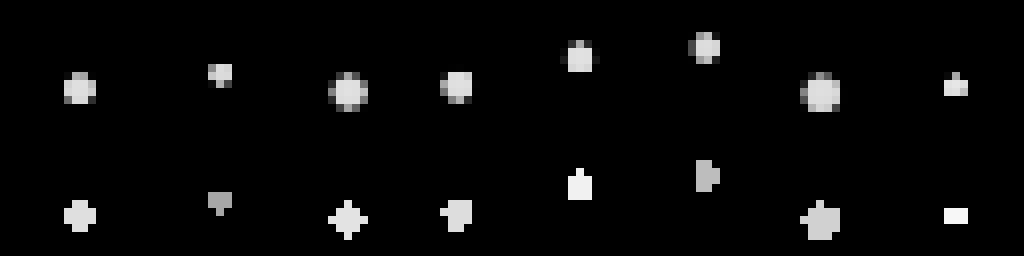

八个真实条件，上行为生成结果，下行为目标。

短复制验证了 4 token 源串、8 token 干扰，三个 seed 的整串错误率均为零。长复制参数变化后的测试失败。视频只验证了 16×16 单物体的 4 帧到 2 帧预测。原始 4 帧到 8 帧尚未解决。多步向量、图和场原型直接输出未来多个时刻，尚未验证预测结果递归回填的长期稳定性。

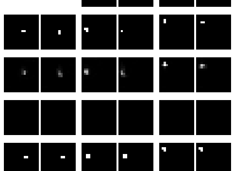

三组真实样本，各组两列为未来两帧。四行依次为目标、卷积网络预测、全零预测、重复最后输入帧。

这些实例和候选经过探索筛选，当前结果证明原型可运行和生成题目。跨数据生成 seed 的稳定难度尚未验证，也不能代表自然图像或真实语言建模。

## 同一组题目上的答对率可与平衡选项基线比较

每类取一道冻结的三选一题目。模型只读题目和选项，预测相同预算下哪个候选效果最好。所有模型读相同题目，不调用工具。GPT 使用聊天接口，最多输出 8192 token，medium reasoning effort，temperature 使用服务默认值。Claude 使用 CLI，显式指定系统提示并禁用工具。

两类模型的请求路径不同。耗时包含接口传输与服务等待，不能据此比较模型架构的推理效率。token 按各服务返回口径统计。

评测前仅重排选项位置，候选和训练结果不变。正确答案分布为 A 5 道、B 5 道、C 5 道。随机选项基线为 33.3%，始终选同一字母的最佳基线为 33.3%。每类只有一道题，结果只能描述这组样本，不能证明整个题型的难度。

部分模型未取得全部 15 道题的有效回答。图中准确率的分母不同，当前不能对四个模型做完整排名。

四个模型都取得有效回答的题目中，7 道全对，0 道结果分歧，2 道全错。全对例子包括带干扰的延迟复制、小型语言模型从头预训练、条件图像 diffusion。全错例子包括随机小模型 next-token、混合阶数 token 预测。这只描述当前候选组合下的单道题表现，架构与预算变化会改变难度。

[figure not shown]

橙条只统计有效回答，请求失败不视为能力错误。

6-luna 首轮接口配额不足后，在另一接口重测整组题。Claude 只对传输失败的请求恢复一次，保留已有有效回答。恢复过程只处理请求失败，不按答题对错重试。

**答题准确率、请求失败与推理开销**

答对数以全部 15 道题为分母单独列出。有效回答列按成功解析且模型身份相符的回答计算准确率。请求失败／格式失败分别计数。耗时是有效回答的请求耗时中位数，单位秒。token 是有效回答累计的输入／输出数。Claude 输入数包含普通输入、写入缓存与读取缓存，GPT 使用服务返回的总输入数。

| 模型 | 答对／题目 | 有效回答，准确率 | 请求／格式失败 | 耗时中位数 | 输入／输出 token |
| --- | --- | --- | --- | --- | --- |
| 6-luna `gpt-6-luna` | 10/15 | 15，66.7% | 0 / 0 | 36.0 | 93,440 / 7,898 |
| 6.1 sol `gpt-6.1-sol` | 11/15 | 15，73.3% | 0 / 0 | 8.7 | 93,440 / 3,029 |
| opus 5.5 `claude-opus-5-5` | 8/15 | 11，72.7% | 4 / 0 | 22.2 | 110,454 / 12,641 |
| haiku 5.5 `claude-haiku-5-5` | 9/15 | 12，75.0% | 3 / 0 | 15.4 | 120,060 / 12,215 |

**每道题的结果**

| 题型 | 6-luna | 6.1 sol | opus 5.5 | haiku 5.5 |
| --- | --- | --- | --- | --- |
| 随机小模型 next-token | 错 | 错 | 错 | 错 |
| 混合阶数 token 预测 | 错 | 错 | 错 | 错 |
| 带干扰的延迟复制 | 对 | 对 | 对 | 对 |
| 小型语言模型从头预训练 | 对 | 对 | 对 | 对 |
| 从头 on-policy 蒸馏 | 对 | 对 | 错 | 请求失败 |
| 隐状态时间序列预测 | 错 | 对 | 对 | 请求失败 |
| 延迟动力系统预测 | 错 | 对 | 请求失败 | 对 |
| 合成图像关系分类 | 对 | 对 | 请求失败 | 对 |
| 条件图像 diffusion | 对 | 对 | 对 | 对 |
| 移动形状视频预测 | 错 | 错 | 请求失败 | 错 |
| 图上的最短路 | 对 | 对 | 对 | 对 |
| 图上的动态扩散 | 对 | 对 | 对 | 对 |
| Poisson 解映射 | 对 | 错 | 请求失败 | 请求失败 |
| 热方程时间推进 | 对 | 对 | 对 | 对 |
| 稀疏传感器场重建 | 对 | 对 | 对 | 对 |

## 任务和可执行验收必须一起保存

[MiMo 的固定版本 README](https://huggingface.co/datasets/XiaomiMiMo/MiMo-V2.6-RL-oss/blob/f819cd203f804f4bc6861a933592f8f62fbbdd7c/README.md)把领域、题型与验收方式一起组织。这里借用这一结构，没有在此核验整个语料的质量。可复用经验记录保存任务 spec、候选对照、相同预算、seed 波动、适用范围与失败案例。